# IA para Científicos Sociales

Sesión 1.4: Laboratorio 2 - Validación cruzada y comparación de modelos

Danilo Freire

danilofreire@gmail.com

Department of Data and Decision Sciences  
Emory University

# Laboratorio 2: Validación cruzada y comparación de modelos

## Objetivos del laboratorio

**Lo que vamos a hacer:**

1. Volver al dataset del laboratorio 1
2. Análisis exploratorio extendido
3. Feature engineering básico
4. Validación cruzada en 5 folds
5. Comparar regresión logística vs. árbol
6. Evaluar el mejor modelo en test

**Lo que vamos a practicar:**

- Decisiones de preprocesamiento
- Comparación sistemática de modelos
- Visualización de resultados
- Interpretación de modelos

Hay menos código predefinido. ¡Ustedes van a escribir más!

¡No se preocupen! Les damos una estructura para que puedan completar 😉

## Del lab 1 al lab 2

**En el lab 1 hicimos:**

- Cargamos `indicadores_mundiales.csv`
- Una sola división train/test
- Un modelo: regresión logística
- Métricas en test: precision, recall, ROC-AUC
- Discutimos el umbral de decisión

**Hoy vamos un paso más allá:**

- El mismo dataset, los mismos predictores
- Validación cruzada (5 folds) en lugar de una sola partición
- Dos modelos a comparar: logístico vs. árbol
- Feature engineering: ¿una variable nueva ayuda?
- Evaluación final en test

El objetivo sustantivo sigue siendo el mismo: predecir `crecimiento_alto` a partir de indicadores macro

# Parte 1: Carga y exploración

## Cargar los paquetes

```r
# Cargar paquetes
# install.packages(c("tidymodels", "tidyverse", "rpart")) # Instalar si es necesario
library(tidymodels)
library(tidyverse)
library(rpart) # Para el motor de árbol de decisión

# Configurar tema de ggplot
theme_set(theme_minimal(base_size = 14))
```

O de una forma más automatizada:

```r
paquetes <- c("tidymodels", "tidyverse", "rpart")

# require(): intenta cargar el paquete y devuelve TRUE/FALSE
# Si no está instalado (FALSE), lo instala y carga
# character.only = TRUE: pkg es una variable; sin esto, R buscaría un paquete llamado "pkg"
for (pkg in paquetes) {
  if (!require(pkg, character.only = TRUE)) {
    install.packages(pkg, dependencies = TRUE)
    library(pkg, character.only = TRUE)
  }
}
```

## El dataset: indicadores mundiales

Volvemos al dataset de indicadores mundiales que ya usamos en el lab 1:

```r
# Cargar datos
datos <- read_csv("datos/indicadores_mundiales.csv")
# Lean el archivo directo desde la web:
# datos <- read_csv("https://raw.githubusercontent.com/danilofreire/introduccion-ia-ucu/main/clases/dia-01/datos/indicadores_mundiales.csv")

# Ver estructura
glimpse(datos) # Ver las variables y tipos
```

```
Rows: 179
Columns: 11
$ pais                    <chr> "Angola", "Argelia", "Benín", "Botsuana", "Bur…
$ continente              <chr> "África", "África", "África", "África", "Áfric…
$ gasto_educacion         <dbl> 5.7, 4.0, 3.2, 5.0, 4.6, 4.8, 4.6, 4.3, 5.9, 5…
$ acceso_internet         <dbl> 50.2, 48.0, 34.3, 46.2, 62.5, 66.0, 55.5, 39.1…
$ urbanizacion            <dbl> 69.1, 61.8, 62.9, 68.6, 54.5, 32.3, 57.6, 52.1…
$ gasto_salud             <dbl> 8.3, 7.6, 4.5, 5.5, 4.3, 4.6, 8.3, 6.9, 4.8, 6…
$ inflacion               <dbl> 9.4, 9.2, 10.3, 14.7, 12.2, 11.8, 11.2, 23.4, …
$ desempleo               <dbl> 5.9, 10.0, 7.2, 13.1, 12.7, 9.7, 9.5, 14.0, 9.…
$ inversion_extranjera    <dbl> 2.4, 4.8, 2.5, 4.1, 2.3, 2.3, 5.5, 3.6, 5.2, 1…
$ indice_gobierno_digital <dbl> 0.38, 0.78, 0.13, 0.49, 0.52, 0.33, 0.57, 0.33…
$ crecimiento_alto        <chr> "si", "si", "no", "no", "no", "si", "no", "no"…
```

**Variable objetivo:** `crecimiento_alto` (sí/no) - ¿El país tuvo crecimiento del PIB mayor o igual a 3%?

## Descripción de las variables

| Variable | Descripción | Tipo |
| --- | --- | --- |
| `crecimiento_alto` | PIB creció ≥ 3% (sí/no) | Categórica |
| `gasto_educacion` | Gasto en educación (% del PIB) | Numérica |
| `acceso_internet` | Acceso a internet (% de la población) | Numérica |
| `urbanizacion` | Población urbana (% del total) | Numérica |
| `gasto_salud` | Gasto en salud (% del PIB) | Numérica |
| `inflacion` | Tasa de inflación anual (%) | Numérica |
| `desempleo` | Tasa de desempleo (%) | Numérica |
| `inversion_extranjera` | IED (% del PIB) | Numérica |
| `indice_gobierno_digital` | Índice de gobierno digital (0-1) | Numérica |
| `pais` | Nombre del país | Categórica |
| `continente` | Continente | Categórica |

## Estadísticas descriptivas

Antes de modelar, conviene ver cómo se distribuyen las variables y si difieren entre los grupos de `crecimiento_alto`. Mostramos acá 3 de los 8 predictores

```r
# Resumen rápido de las variables numéricas
datos |> select(gasto_educacion, acceso_internet, urbanizacion) |> summary()
```

```
 gasto_educacion acceso_internet  urbanizacion
 Min.   :2.100   Min.   : 5.00   Min.   :16.40
 1st Qu.:4.400   1st Qu.:46.60   1st Qu.:44.70
 Median :5.000   Median :57.50   Median :58.10
 Mean   :5.027   Mean   :57.52   Mean   :58.42
 3rd Qu.:5.600   3rd Qu.:68.35   3rd Qu.:73.15
 Max.   :8.000   Max.   :99.00   Max.   :97.60
```

```r
# Medias por nivel de crecimiento (3 predictores ilustrativos)
datos |>
  group_by(crecimiento_alto) |>
  summarise(
    educacion_media     = mean(gasto_educacion),
    internet_medio      = mean(acceso_internet),
    urbanizacion_media  = mean(urbanizacion)
  )
```

```
# A tibble: 2 × 4
  crecimiento_alto educacion_media internet_medio urbanizacion_media
  <chr>                      <dbl>          <dbl>              <dbl>
1 no                          4.75           51.8               54.8
2 si                          5.33           63.7               62.3
```

Detalle por variable en Apéndice 2; relaciones con el objetivo en Apéndice 3; visualizaciones en Apéndice 4

## Ejercicio 1: Exploración

**Tarea:** Exploren una de las variables que no mostramos en la diapositiva anterior.

1. ¿Cuántas observaciones? ¿Hay valores faltantes?
2. ¿Cómo se distribuye la variable objetivo `crecimiento_alto`?
3. Elijan una de estas preguntas y respóndanla con una comparación numérica (el gráfico es opcional):
   - Elijan una de `inflacion`, `desempleo`, `inversion_extranjera` o `indice_gobierno_digital` y comparen su media (o mediana) entre países con `crecimiento_alto = "si"` y `"no"`. ¿La diferencia parece grande?
   - ¿Están altamente correlacionados `acceso_internet` y `urbanizacion`? Si lo están, podríamos no necesitar a los dos en el modelo

```r
# Código para empezar
dim(datos)
datos |> count(crecimiento_alto) |> mutate(prop = n / sum(n))

# Ejemplo para la primera pregunta: media de gasto_salud por grupo
datos |>
  group_by(crecimiento_alto) |>
  summarise(media_gasto_salud = mean(gasto_salud))

# Ejemplo para la segunda pregunta: correlación entre dos predictores
cor(datos$acceso_internet, datos$urbanizacion)
```

Tómense 5-10 minutos

App 1: exploración inicial · App 2: ¿media o mediana? · App 3: comparación numérica por grupo · App 4: versión visual (opcional)

# Parte 2: Feature engineering

## Preparar los datos

Convertimos la variable objetivo a factor y descartamos las columnas que no usaremos como predictores. `pais` tiene 179 valores únicos y `continente` la dejamos fuera para quedarnos con predictores numéricos, igual que en el lab 1.

Creamos un nuevo objeto `datos_modelo` y mantenemos `datos` intacto para los apéndices y la exploración:

```r
# Frame listo para modelar (datos sigue intacto con pais y continente)
datos_modelo <- datos |>
  mutate(crecimiento_alto = factor(crecimiento_alto, levels = c("no", "si"))) |>
  select(-pais, -continente)

# Verificar
glimpse(datos_modelo)
```

```
Rows: 179
Columns: 9
$ gasto_educacion         <dbl> 5.7, 4.0, 3.2, 5.0, 4.6, 4.8, 4.6, 4.3, 5.9, 5…
$ acceso_internet         <dbl> 50.2, 48.0, 34.3, 46.2, 62.5, 66.0, 55.5, 39.1…
$ urbanizacion            <dbl> 69.1, 61.8, 62.9, 68.6, 54.5, 32.3, 57.6, 52.1…
$ gasto_salud             <dbl> 8.3, 7.6, 4.5, 5.5, 4.3, 4.6, 8.3, 6.9, 4.8, 6…
$ inflacion               <dbl> 9.4, 9.2, 10.3, 14.7, 12.2, 11.8, 11.2, 23.4, …
$ desempleo               <dbl> 5.9, 10.0, 7.2, 13.1, 12.7, 9.7, 9.5, 14.0, 9.…
$ inversion_extranjera    <dbl> 2.4, 4.8, 2.5, 4.1, 2.3, 2.3, 5.5, 3.6, 5.2, 1…
$ indice_gobierno_digital <dbl> 0.38, 0.78, 0.13, 0.49, 0.52, 0.33, 0.57, 0.33…
$ crecimiento_alto        <fct> si, si, no, no, no, si, no, no, si, no, no, no…
```

Mantenemos el orden `c("no", "si")` para que `"si"` sea la clase positiva. Más adelante usaremos `event_level = "second"`

## Crear nuevas variables

El feature engineering puede mejorar el rendimiento del modelo:

```r
# Crear nuevas variables sobre el frame que va al modelo
datos_modelo <- datos_modelo |>
  mutate(
    # Grupos de urbanización (rural, mixto, urbano)
    grupo_urbanizacion = cut(urbanizacion,
                             breaks = c(0, 50, 75, 100),
                             labels = c("rural", "mixto", "urbano"),
                             include.lowest = TRUE),

    # Intensidad fiscal social: cuánto del PIB va a salud + educación
    gasto_social = gasto_educacion + gasto_salud,

    # Indicador de alto desempleo (lo usaremos como ejemplo más adelante)
    alto_desempleo = factor(if_else(desempleo > 7, "alto", "bajo"))
  )

# Ver las nuevas variables
datos_modelo |> select(grupo_urbanizacion, gasto_social, alto_desempleo) |> head()
```

```
# A tibble: 6 × 3
  grupo_urbanizacion gasto_social alto_desempleo
  <fct>                     <dbl> <fct>
1 mixto                      14   bajo
2 mixto                      11.6 alto
3 mixto                       7.7 alto
4 mixto                      10.5 alto
5 mixto                       8.9 alto
6 rural                       9.4 alto
```

## Ejercicio 2: Crear un feature

**Tarea:** Elijan una variable derivada y créenla

Opciones sugeridas (elijan la que más les interese). Entre paréntesis, la variable base:

- Acceso a internet por terciles: bajo, medio, alto (`acceso_internet`)
- Gasto en educación alto: por encima de la mediana del dataset (`gasto_educacion`)
- Inflación alta: tasa mayor a 15% (`inflacion`)
- Apertura financiera: IED por encima de la mediana (`inversion_extranjera`)
- Otro que se les ocurra (¡la creatividad es bienvenida!)

```r
# Ejemplo: crear variable internet_grupos por terciles
datos_modelo <- datos_modelo |>
  mutate(
    internet_grupos = cut(acceso_internet,
                          breaks = quantile(acceso_internet, c(0, 1/3, 2/3, 1)),
                          labels = c("bajo", "medio", "alto"),
                          include.lowest = TRUE)
  )
```

¡Tómense 3-5 minutos!

Más ejemplos en el Apéndice 5

## Dividir los datos

```r
# Fijar semilla
set.seed(2026)

# Dividir datos (usando el frame con la variable objetivo como factor)
datos_split <- initial_split(datos_modelo, prop = 0.75, strata = crecimiento_alto)
datos_train <- training(datos_split)
datos_test <- testing(datos_split)

# Crear folds para validación cruzada
folds <- vfold_cv(datos_train, v = 5, strata = crecimiento_alto)

cat("Train:", nrow(datos_train), "| Test:", nrow(datos_test))
```

```
Train: 133 | Test: 46
```

- `initial_split()`: Divide el dataset en train/test
- `training()` y `testing()`: Extraen los datasets de train y test
- `vfold_cv()`: Crea folds para validación cruzada (5 folds, estratificados por `crecimiento_alto`)

Con 179 países y 5 folds, cada partición tiene pocos países en validación. Es suficiente para entrenar, pero las métricas tendrán más ruido

# Parte 3: Comparación de modelos

## Definir los modelos a comparar

Vamos a comparar dos modelos de naturaleza distinta: uno lineal y uno no lineal

```r
# 1. Regresión logística (lineal)
modelo_logistico <- logistic_reg() |>
  set_engine("glm") |>
  set_mode("classification")

# 2. Árbol de decisión (no lineal, captura interacciones automáticamente)
modelo_arbol <- decision_tree() |>
  set_engine("rpart") |>
  set_mode("classification")
```

La misma sintaxis sirve para ambos: esa es la ventaja de `parsnip`. Otros motores (`kknn`, `ranger`, `xgboost`) funcionan igual cambiando solo `set_engine()`

Una vez más, la lista de modelos disponibles está en https://www.tidymodels.org/find/parsnip/

## Crear una fórmula

Decidamos qué variables usar:

```r
# Fórmula con las 8 variables numéricas originales
formula_basica <- crecimiento_alto ~ gasto_educacion + acceso_internet +
                                     urbanizacion + gasto_salud + inflacion +
                                     desempleo + inversion_extranjera +
                                     indice_gobierno_digital
```

Más adelante añadiremos una variable derivada para ver si mejora el ajuste

## Evaluar el modelo logístico

Validación cruzada en 5 folds y resumen de métricas:

```r
# Las tres métricas juntas en un objeto que vamos a reusar todo el lab
mis_metricas <- metric_set(precision, recall, roc_auc)

eval_logistico <- fit_resamples(
  modelo_logistico, formula_basica,
  resamples = folds,
  metrics = mis_metricas,
  control = control_resamples(event_level = "second")   # "si" es la clase positiva
) |>
  collect_metrics() |>
  mutate(modelo = "Logístico")

eval_logistico
```

```
# A tibble: 3 × 7
  .metric   .estimator  mean     n std_err .config         modelo
  <chr>     <chr>      <dbl> <int>   <dbl> <chr>           <chr>
1 precision binary     0.768     5  0.0714 pre0_mod0_post0 Logístico
2 recall    binary     0.782     5  0.0559 pre0_mod0_post0 Logístico
3 roc_auc   binary     0.846     5  0.0512 pre0_mod0_post0 Logístico
```

- `fit_resamples()` ajusta el modelo [en cada fold de la validación cruzada](https://tune.tidymodels.org/reference/fit_resamples.html)
- `metric_set()` junta [varias métricas en un solo objeto](https://yardstick.tidymodels.org/reference/metric_set.html). Lo guardamos en `mis_metricas` y lo reusamos en cada evaluación
- `collect_metrics()` devuelve la media y el error estándar de [cada métrica entre folds](https://tune.tidymodels.org/reference/collect_predictions.html)
- `control = control_resamples(event_level = "second")` indica que la clase positiva es `"si"`
- Usamos precision, recall y roc_auc en lugar de accuracy: con clases desbalanceadas la accuracy puede ser engañosa
- En el resultado, `.metric` guarda el nombre de cada métrica (`precision`, `recall`, `roc_auc`) y `mean` y `std_err`

## Evaluar el árbol y comparar

```r
# El mismo bloque que antes, cambiando modelo_logistico → modelo_arbol
eval_arbol <- fit_resamples(
  modelo_arbol, formula_basica,
  resamples = folds,
  metrics = mis_metricas,
  control = control_resamples(event_level = "second")
) |>
  collect_metrics() |>
  mutate(modelo = "Árbol")

# Combinar y mostrar la comparación
resultados <- bind_rows(eval_logistico, eval_arbol)

# Una fila por modelo y métrica, ordenadas para comparar de a pares
resultados |>
  select(modelo, .metric, mean, std_err) |>
  arrange(.metric, modelo)
```

```
# A tibble: 6 × 4
  modelo    .metric    mean std_err
  <chr>     <chr>     <dbl>   <dbl>
1 Logístico precision 0.768  0.0714
2 Árbol     precision 0.686  0.0453
3 Logístico recall    0.782  0.0559
4 Árbol     recall    0.706  0.0813
5 Logístico roc_auc   0.846  0.0512
6 Árbol     roc_auc   0.717  0.0501
```

Versión visual de esta comparación (barras con error estándar) en Apéndice 7

## ¿Qué pasa si extendemos la fórmula?

Antes de pedirles que prueben su propia variable, miremos un ejemplo trabajado. Reemplazamos `desempleo` (continuo) por `alto_desempleo` (binario, la creamos antes en la demo) y re-evaluamos el modelo logístico:

```r
# Fórmula extendida con un feature derivado
formula_ext <- crecimiento_alto ~ acceso_internet + gasto_educacion + urbanizacion + gasto_salud + inflacion +
                                  alto_desempleo + inversion_extranjera + indice_gobierno_digital

# Logístico con formula_ext
eval_log_ext <- fit_resamples(modelo_logistico, formula_ext, resamples = folds,
  metrics = mis_metricas,
  control = control_resamples(event_level = "second")) |>
  collect_metrics() |> mutate(modelo = "Logístico (ext)")

# Comparar el logístico básico vs. el extendido
bind_rows(eval_logistico, eval_log_ext) |>
  select(modelo, .metric, mean, std_err) |>
  arrange(.metric, modelo)
```

```
# A tibble: 6 × 4
  modelo          .metric    mean std_err
  <chr>           <chr>     <dbl>   <dbl>
1 Logístico       precision 0.768  0.0714
2 Logístico (ext) precision 0.787  0.0640
3 Logístico       recall    0.782  0.0559
4 Logístico (ext) recall    0.799  0.0514
5 Logístico       roc_auc   0.846  0.0512
6 Logístico (ext) roc_auc   0.850  0.0580
```

## Ejercicio 3: ¿Ayuda el feature engineering?

**Tarea:** Agreguen un feature a la fórmula y re-evalúen: la variable que crearon en el Ejercicio 2, o una interacción entre dos variables (como en el ejemplo)

1. ¿Mejora la regresión logística? ¿Y el árbol?
2. ¿Cuál de los dos modelos es más sensible al feature nuevo?

```r
# Ejemplo: una interacción entre dos variables que se refuerzan
# (gobierno digital y acceso a internet). En una fórmula se escribe con ":"
formula_estudiante <- crecimiento_alto ~ gasto_educacion + acceso_internet +
                                         urbanizacion + gasto_salud + inflacion +
                                         desempleo + inversion_extranjera +
                                         indice_gobierno_digital +
                                         indice_gobierno_digital:acceso_internet

# Repetir el mismo bloque, ahora con formula_estudiante
eval_log_est <- fit_resamples(modelo_logistico, formula_estudiante, resamples = folds,
  metrics = mis_metricas,
  control = control_resamples(event_level = "second")) |>
  collect_metrics() |> mutate(modelo = "Logístico (estudiante)")

# Lo mismo cambiando modelo_logistico → modelo_arbol
eval_arb_est <- fit_resamples(modelo_arbol, formula_estudiante, resamples = folds,
  metrics = mis_metricas,
  control = control_resamples(event_level = "second")) |>
  collect_metrics() |> mutate(modelo = "Árbol (estudiante)")

# Comparar los 4 modelos: básicos + el suyo
bind_rows(eval_logistico, eval_log_est, eval_arbol, eval_arb_est) |>
  filter(.metric == "roc_auc") |> select(modelo, mean, std_err)
```

¡Tómense 5 minutos!

Ir al Apéndice 6

## Modelo final en datos de test

Una vez elegido el mejor modelo por validación cruzada, lo entrenamos con todos los datos de train y lo evaluamos una sola vez en test (los datos que el modelo nunca vio):

```r
# Entrenar el modelo elegido con todos los datos de train
ajuste_final <- modelo_logistico |>
  fit(formula_ext, data = datos_train)

# augment() junta predicciones (clases + probabilidades) con los datos originales
# en una sola línea. Equivale a hacer dos predict() + bind_cols().
pred_test <- ajuste_final |> augment(datos_test)

# Métricas finales: el mismo mis_metricas de la validación cruzada
pred_test |> mis_metricas(truth = crecimiento_alto, estimate = .pred_class, .pred_si, event_level = "second")
```

```
# A tibble: 3 × 3
  .metric   .estimator .estimate
  <chr>     <chr>          <dbl>
1 precision binary         0.783
2 recall    binary         0.818
3 roc_auc   binary         0.888
```

- `augment()` toma un modelo ajustado y un conjunto de datos, y añade las predicciones como columnas nuevas: `.pred_class` (clase predicha), `.pred_no`, `.pred_si` (probabilidades)
- El prefijo `.` es la convención de tidymodels para columnas que el paquete crea por ustedes
- Reemplaza dos llamadas a `predict()` y dos `bind_cols()` por una sola línea
- `mis_metricas` devuelve las tres métricas en una sola tabla. Necesita las dos cosas: `estimate = .pred_class` para precision y recall, y `.pred_si` (la probabilidad) para el roc_auc

## Tarea para casa

Hay una tarea para las dos sesiones con preguntas prácticas que aplican todo lo que vimos hoy.

- Página de [Laboratorios](https://danilofreire.github.io/introduccion-ia-ucu/laboratorios.html) del sitio del curso
- [Tarea 1](https://danilofreire.github.io/introduccion-ia-ucu/clases/dia-01/tarea-01.html)
- [Respuestas Tarea 1](https://danilofreire.github.io/introduccion-ia-ucu/clases/dia-01/tarea-01-respuestas.html)
- [Tarea 2](https://danilofreire.github.io/introduccion-ia-ucu/clases/dia-01/tarea-02.html)
- [Respuestas Tarea 2](https://danilofreire.github.io/introduccion-ia-ucu/clases/dia-01/tarea-02-respuestas.html)

Las respuestas ya están disponibles para que verifiquen su trabajo 😉

# Cierre del Día 1

## Lo que cubrimos hoy

**Sesión 1.1: ¿Qué es la IA?**

- Definición y tipos de IA
- Historia: de Turing a GPT
- Tipos de aprendizaje automático
- Ética básica

**Sesión 1.2: Fundamentos de ML**

- Flujo de trabajo de ML
- División y validación
- Sobreajuste y sesgo-varianza
- Métricas de evaluación

**Sesión 1.3: Laboratorio 1**

- Ecosistema tidymodels
- Primer modelo de clasificación
- Matriz de confusión y métricas

**Sesión 1.4: Laboratorio 2**

- Exploración extendida con el mismo dataset
- Feature engineering básico
- Logístico vs. árbol con validación cruzada
- Tarea 2 disponible en la página de laboratorios

## Para mañana

**Día 2: Aprendizaje supervisado**

- Sesión 2.1: Métodos de clasificación
  - Regresión logística en detalle, árboles de decisión, Random Forests
- Sesión 2.2: Regresión y predicción
  - Regularización (LASSO, Ridge, Elastic Net) e ingeniería de variables
- Sesiones 2.3 y 2.4: Laboratorios con datos de Latinobarómetro

**Para profundizar (todo gratis):** [Tidy Modeling with R](https://www.tmwr.org/) – [R for Data Science](https://r4ds.hadley.nz/) – [Get Started with tidymodels](https://www.tidymodels.org/start/)

¡Descansen y vengan con energía mañana! 😄

# Fin del Día 1 🥳

# Apéndices

## Apéndice 1: Exploración inicial

```r
# 1. Dimensiones
dim(datos)
```

```
[1] 179  11
```

```r
# 2. Distribución de la variable objetivo
datos |>
  count(crecimiento_alto) |>
  mutate(prop = round(n / sum(n), 3))
```

```
# A tibble: 2 × 3
  crecimiento_alto     n  prop
  <chr>            <int> <dbl>
1 no                  93  0.52
2 si                  86  0.48
```

```r
# 3. Valores faltantes por variable
colSums(is.na(datos))
```

```
                   pais              continente         gasto_educacion
                      0                       0                       0
        acceso_internet            urbanizacion             gasto_salud
                      0                       0                       0
              inflacion               desempleo    inversion_extranjera
                      0                       0                       0
indice_gobierno_digital        crecimiento_alto
                      0                       0
```

```r
# 4. Resumen de variables numéricas
datos |>
  select(where(is.numeric)) |>
  summary()
```

```
 gasto_educacion acceso_internet  urbanizacion    gasto_salud
 Min.   :2.100   Min.   : 5.00   Min.   :16.40   Min.   :3.200
 1st Qu.:4.400   1st Qu.:46.60   1st Qu.:44.70   1st Qu.:5.800
 Median :5.000   Median :57.50   Median :58.10   Median :6.700
 Mean   :5.027   Mean   :57.52   Mean   :58.42   Mean   :6.631
 3rd Qu.:5.600   3rd Qu.:68.35   3rd Qu.:73.15   3rd Qu.:7.450
 Max.   :8.000   Max.   :99.00   Max.   :97.60   Max.   :9.500
   inflacion       desempleo      inversion_extranjera indice_gobierno_digital
 Min.   : 5.20   Min.   : 1.500   Min.   :0.200        Min.   :0.0800
 1st Qu.: 9.35   1st Qu.: 6.700   1st Qu.:3.050        1st Qu.:0.4050
 Median :11.70   Median : 8.400   Median :4.200        Median :0.5200
 Mean   :12.73   Mean   : 8.434   Mean   :4.079        Mean   :0.5136
 3rd Qu.:14.70   3rd Qu.:10.100   3rd Qu.:5.100        3rd Qu.:0.6350
 Max.   :37.40   Max.   :16.100   Max.   :7.400        Max.   :0.9600
```

Volver al Ejercicio 1

## Apéndice 2: Una variable a fondo

El Ejercicio 1 les pide comparar la media o la mediana. ¿Cuándo conviene usar la mediana? Cuando la variable tiene cola larga y la media deja de representarla bien. Tomemos `inflacion`: tiene cola larga, así que la media (≈ 12.7) es mayor que la mediana (≈ 11.7), y hay países con inflación de hasta ~37% que estiran el promedio:

```r
# Estadísticas detalladas
summary(datos$inflacion)
```

```
   Min. 1st Qu.  Median    Mean 3rd Qu.    Max.
   5.20    9.35   11.70   12.73   14.70   37.40
```

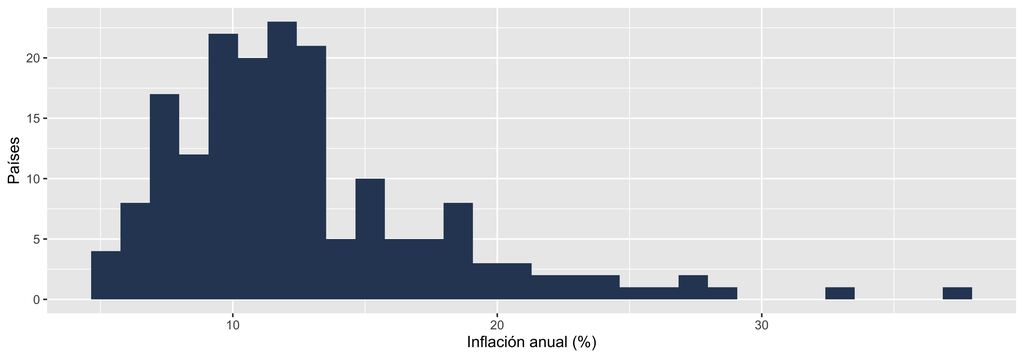

```r
# Histograma (muestra la cola larga)
ggplot(datos, aes(x = inflacion)) +
  geom_histogram(bins = 30, fill = "#2d4563") +
  labs(x = "Inflación anual (%)", y = "Países")
```

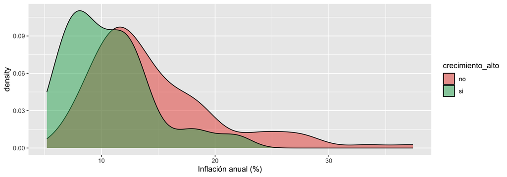

```r
# Densidad por grupo (¿separa crecimiento alto de bajo?)
ggplot(datos, aes(x = inflacion, fill = crecimiento_alto)) +
  geom_density(alpha = 0.5) +
  scale_fill_manual(values = c("#e74c3c", "#27ae60")) +
  labs(x = "Inflación anual (%)")
```

Cambien el nombre de la variable (`gasto_salud`, `desempleo`, `indice_gobierno_digital`, etc.) para repetir el análisis con otra. La mayoría de los predictores son casi simétricos; `inflacion` es la excepción

Volver al Ejercicio 1

## Apéndice 3: Predictores vs. objetivo

Esta es la comparación numérica que pide el ejercicio: las medias por grupo son la pista más rápida, porque si difieren mucho, la variable probablemente ayudará al modelo. Acá las 5 que no mostramos en el cuerpo:

```r
# Medias por grupo de las 4 variables no mostradas en el cuerpo
datos |>
  group_by(crecimiento_alto) |>
  summarise(
    salud         = mean(gasto_salud),
    inflacion     = mean(inflacion),
    desempleo     = mean(desempleo),
    ied           = mean(inversion_extranjera),
    gob_digital   = mean(indice_gobierno_digital)
  )
```

```
# A tibble: 2 × 6
  crecimiento_alto salud inflacion desempleo   ied gob_digital
  <chr>            <dbl>     <dbl>     <dbl> <dbl>       <dbl>
1 no                6.40      14.7      9.56  3.50       0.438
2 si                6.88      10.6      7.22  4.70       0.595
```

```r
# Correlación entre todos los predictores numéricos (¿hay pares redundantes?)
datos |>
  select(where(is.numeric)) |>
  cor() |>
  round(2)
```

```
                        gasto_educacion acceso_internet urbanizacion
gasto_educacion                    1.00            0.07         0.24
acceso_internet                    0.07            1.00         0.10
urbanizacion                       0.24            0.10         1.00
gasto_salud                        0.26            0.09         0.21
inflacion                         -0.08           -0.05        -0.13
desempleo                         -0.22           -0.13        -0.28
inversion_extranjera               0.21            0.17         0.14
indice_gobierno_digital            0.18            0.20         0.21
                        gasto_salud inflacion desempleo inversion_extranjera
gasto_educacion                0.26     -0.08     -0.22                 0.21
acceso_internet                0.09     -0.05     -0.13                 0.17
urbanizacion                   0.21     -0.13     -0.28                 0.14
gasto_salud                    1.00     -0.17     -0.15                 0.09
inflacion                     -0.17      1.00      0.18                -0.18
desempleo                     -0.15      0.18      1.00                -0.18
inversion_extranjera           0.09     -0.18     -0.18                 1.00
indice_gobierno_digital        0.32     -0.28     -0.30                 0.39
                        indice_gobierno_digital
gasto_educacion                            0.18
acceso_internet                            0.20
urbanizacion                               0.21
gasto_salud                                0.32
inflacion                                 -0.28
desempleo                                 -0.30
inversion_extranjera                       0.39
indice_gobierno_digital                    1.00
```

```r
# Test formal para una variable concreta
t.test(indice_gobierno_digital ~ crecimiento_alto, data = datos)
```

```
    Welch Two Sample t-test

data:  indice_gobierno_digital by crecimiento_alto
t = -6.8831, df = 175.49, p-value = 9.985e-11
alternative hypothesis: true difference in means between group no and group si is not equal to 0
95 percent confidence interval:
 -0.2023819 -0.1121868
sample estimates:
mean in group no mean in group si
       0.4380645        0.5953488
```

Volver al Ejercicio 1

## Apéndice 4: Boxplots de las 4 variables no mostradas

Versión visual (opcional) de la primera pregunta: las mismas diferencias de medias del Apéndice 3, ahora como boxplots. ¿Alguna de las cuatro variables que no aparecen en las estadísticas descriptivas separa bien `crecimiento_alto`?

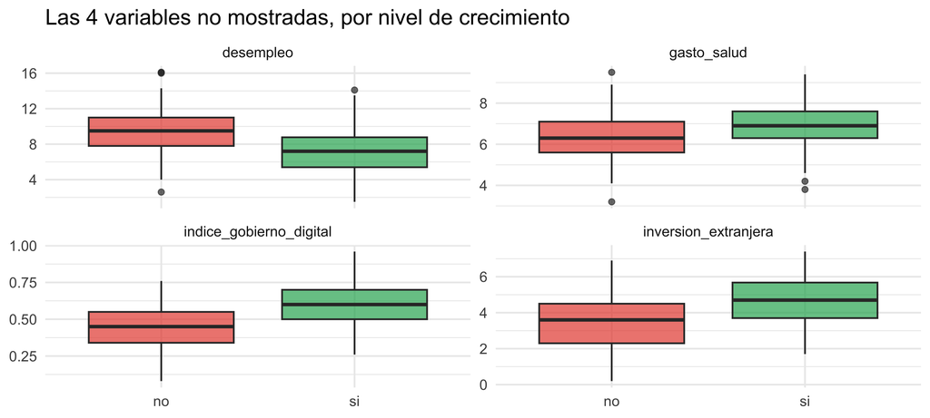

```r
datos |>
  select(crecimiento_alto, gasto_salud, desempleo, inversion_extranjera, indice_gobierno_digital) |>
  pivot_longer(-crecimiento_alto, names_to = "variable", values_to = "valor") |>
  ggplot(aes(x = crecimiento_alto, y = valor, fill = crecimiento_alto)) +
  geom_boxplot(alpha = 0.7) +
  facet_wrap(~variable, scales = "free_y") +
  scale_fill_manual(values = c("#e74c3c", "#27ae60")) +
  labs(title = "Las 4 variables no mostradas, por nivel de crecimiento", x = NULL, y = NULL) +
  theme(legend.position = "none")
```

Volver al Ejercicio 1

## Apéndice 4 (cont.): Acceso a internet vs. urbanización

Versión visual (opcional) de la segunda pregunta. Si la nube de puntos cae cerca de una recta, los dos predictores capturan información parecida (colinealidad):

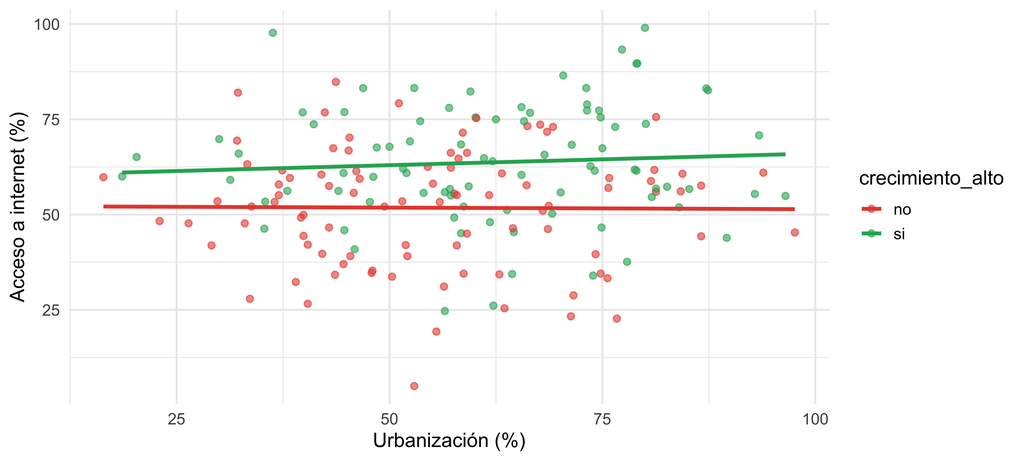

```r
ggplot(datos, aes(x = urbanizacion, y = acceso_internet, color = crecimiento_alto)) +
  geom_point(alpha = 0.6) +
  geom_smooth(method = "lm", se = FALSE) +
  scale_color_manual(values = c("#e74c3c", "#27ae60")) +
  labs(x = "Urbanización (%)", y = "Acceso a internet (%)")
```

```r
# La correlación numérica complementa el gráfico
cor(datos$urbanizacion, datos$acceso_internet)
```

```
[1] 0.1032229
```

Volver al Ejercicio 1

## Apéndice 5: Crear más features

```r
# Una posible solución para cada una de las cuatro opciones sugeridas
datos_modelo <- datos_modelo |>
  mutate(
    # 1. Gasto en educación alto (gasto_educacion)
    educacion_alta = if_else(gasto_educacion > median(gasto_educacion), "alta", "baja"),

    # 2. Acceso a internet por terciles (acceso_internet)
    internet_grupos = cut(acceso_internet,
                          breaks = quantile(acceso_internet, c(0, 1/3, 2/3, 1)),
                          labels = c("bajo", "medio", "alto"),
                          include.lowest = TRUE),

    # 3. Inflación alta (inflacion)
    inflacion_alta = if_else(inflacion > 15, "si", "no"),

    # 4. Apertura financiera: IED por encima de la mediana (inversion_extranjera)
    apertura_financiera = if_else(inversion_extranjera > median(inversion_extranjera), "alta", "baja")
  )

# Verificar las nuevas variables
datos_modelo |> count(educacion_alta)
```

```
# A tibble: 2 × 2
  educacion_alta     n
  <chr>          <int>
1 alta              87
2 baja              92
```

```r
datos_modelo |> count(internet_grupos)
```

```
# A tibble: 3 × 2
  internet_grupos     n
  <fct>           <int>
1 bajo               60
2 medio              59
3 alto               60
```

```r
datos_modelo |> count(inflacion_alta)
```

```
# A tibble: 2 × 2
  inflacion_alta     n
  <chr>          <int>
1 no               140
2 si                39
```

```r
datos_modelo |> count(apertura_financiera)
```

```
# A tibble: 2 × 2
  apertura_financiera     n
  <chr>               <int>
1 alta                   83
2 baja                   96
```

Volver al Ejercicio 2

## Apéndice 6: ¿Ayuda el feature engineering?

```r
# Una interacción no necesita una columna nueva: se agrega a la fórmula con ":".
# Probamos indice_gobierno_digital × acceso_internet (dos variables que se refuerzan)
formula_int <- crecimiento_alto ~ gasto_educacion + acceso_internet +
                                  urbanizacion + gasto_salud + inflacion +
                                  desempleo + inversion_extranjera +
                                  indice_gobierno_digital +
                                  indice_gobierno_digital:acceso_internet

# Evaluar el logístico (reusamos los mismos folds del cuerpo del lab)
eval_log_int <- fit_resamples(
  modelo_logistico, formula_int, resamples = folds,
  metrics = mis_metricas,
  control = control_resamples(event_level = "second")
) |>
  collect_metrics() |> mutate(modelo = "Logístico (interacción)")

# Evaluar el árbol con la misma fórmula
eval_arb_int <- fit_resamples(
  modelo_arbol, formula_int, resamples = folds,
  metrics = mis_metricas,
  control = control_resamples(event_level = "second")
) |>
  collect_metrics() |> mutate(modelo = "Árbol (interacción)")

bind_rows(eval_logistico, eval_log_int, eval_arbol, eval_arb_int) |>
  filter(.metric == "roc_auc") |>
  select(modelo, mean, std_err) |>
  arrange(desc(mean))
```

```
# A tibble: 4 × 3
  modelo                   mean std_err
  <chr>                   <dbl>   <dbl>
1 Logístico (interacción) 0.851  0.0483
2 Logístico               0.846  0.0512
3 Árbol (interacción)     0.738  0.0687
4 Árbol                   0.717  0.0501
```

Volver al Ejercicio 3

## Apéndice 7: Visualizar la comparación de modelos

Una alternativa visual al cuadro de comparación:

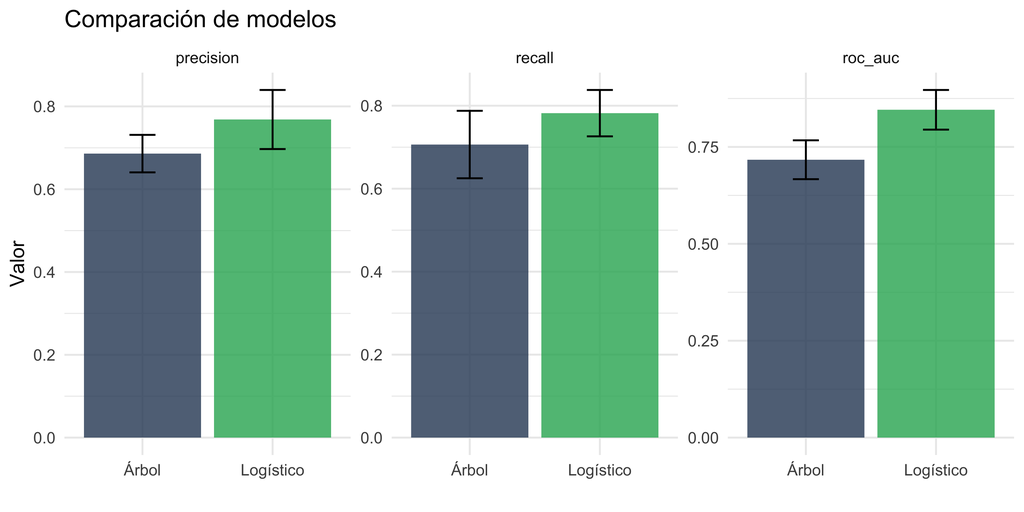

```r
resultados |>
  ggplot(aes(x = modelo, y = mean, fill = modelo)) +
  geom_col(alpha = 0.8) +
  geom_errorbar(aes(ymin = mean - std_err, ymax = mean + std_err),
                width = 0.2) +
  facet_wrap(~.metric, scales = "free_y") +
  scale_fill_manual(values = c("#2d4563", "#27ae60")) +
  labs(title = "Comparación de modelos", y = "Valor", x = "") +
  theme(legend.position = "none")
```

- Las barras muestran la media de cada métrica; las líneas verticales son el error estándar (variabilidad entre folds)
- Si las barras de error se superponen, la diferencia entre modelos no es robusta: probablemente no podamos decir cuál es “mejor” con confianza

Volver a la comparación numérica